# Assignment 3

Aigerim Kulzhabayeva

23 June 2019

### Exercise

In this exersice we will try to estimate the gender gap under various circumstances and find the conditions for which gender gap is largest and smallest.

#### 1. We will specify a model with following variables:

Level 0 (student) variables

- ses - socioeconomic status
- Sex - Male, Female

Level 1 (school) variables

- ses.m - mean of the ses in individual schools (compositional variable)
- Sex_Female - proportoin of female students in individual school
- Sector - Public, Catholic

#### Model 1

```r
#fits <- lme( mathach ~ (ses + ses.m + Sex_Female) * Sector, dd,random = ~ 1 + ses*Sex | school )
```

This model failed to converge. To remedy this lets try to simply increase the number of iterations.

```r
#fits <- lme( mathach ~ (dvar(ses,school) + ses.m + Sex_Female) * Sector, dd,
            # random = ~ 1 + dvar(ses,school)*Sex | school ,
            # control = list( maxIter = 200, msMaxIter = 200,niterEM = 100, msVerbose = FALSE))
```

Model still fails to converge. Random intercept and random effect of ses are blowing up. As a next try, lets center ses within mean of each school by creating variable ses.cwg and including it in the model.

```r
fits <- lme( mathach ~ (ses.cwg + ses.m + Sex_Female + Sex) * Sector, dd,
             random = ~ 1 + ses.cwg*Sex | school ,
             control = list( maxIter = 200, msMaxIter = 200,niterEM = 100, msVerbose = FALSE))
```

This model converges, lets look at the summary.

```
## Linear mixed-effects model fit by REML
##  Data: dd
##        AIC      BIC    logLik
##   12832.75 12950.02 -6395.375
##
## Random effects:
##  Formula: ~1 + ses.cwg * Sex | school
##  Structure: General positive-definite, Log-Cholesky parametrization
##                   StdDev   Corr
## (Intercept)       1.624816 (Intr) ss.cwg SexFml
## ses.cwg           1.198604  0.126
## SexFemale         0.957364 -0.686  0.625
## ses.cwg:SexFemale 1.667642 -0.029 -0.991 -0.701
## Residual          6.074160
##
## Fixed effects: mathach ~ (ses.cwg + ses.m + Sex_Female + Sex) * Sector
##                             Value Std.Error   DF   t-value p-value
## (Intercept)             14.356889  0.701553 1933 20.464437  0.0000
## ses.cwg                  1.833110  0.314687 1933  5.825193  0.0000
## ses.m                    4.109950  0.939721   34  4.373585  0.0001
## Sex_Female              -0.306203  1.117004   34 -0.274128  0.7856
## SexFemale               -1.472149  0.609523 1933 -2.415247  0.0158
## SectorPublic            -0.378848  2.527987   34 -0.149861  0.8818
## ses.cwg:SectorPublic     1.090446  0.462659 1933  2.356909  0.0185
## ses.m:SectorPublic       1.869489  1.269738   34  1.472343  0.1501
## Sex_Female:SectorPublic -1.860776  4.861412   34 -0.382765  0.7043
## SexFemale:SectorPublic   0.518561  0.772906 1933  0.670924  0.5023
##  Correlation:
##                         (Intr) ss.cwg ses.m  Sx_Fml SexFml SctrPb ss.c:SP
## ses.cwg                  0.085
## ses.m                   -0.082  0.034
## Sex_Female              -0.692 -0.104  0.029
## SexFemale               -0.120  0.049 -0.079 -0.493
## SectorPublic            -0.278 -0.024  0.023  0.192  0.033
## ses.cwg:SectorPublic    -0.058 -0.680 -0.023  0.071 -0.033  0.028
## ses.m:SectorPublic       0.061 -0.025 -0.740 -0.021  0.059 -0.117  0.020
## Sex_Female:SectorPublic  0.159  0.024 -0.007 -0.230  0.113 -0.959 -0.023
## SexFemale:SectorPublic   0.095 -0.039  0.063  0.389 -0.789 -0.059  0.067
##                         ss.m:SP S_F:SP
## ses.cwg
## ses.m
## Sex_Female
## SexFemale
## SectorPublic
## ses.cwg:SectorPublic
## ses.m:SectorPublic
## Sex_Female:SectorPublic  0.140
## SexFemale:SectorPublic  -0.048  -0.134
##
## Standardized Within-Group Residuals:
##         Min          Q1         Med          Q3         Max
## -3.10706261 -0.74965514  0.03340747  0.78587428  2.69738248
##
## Number of Observations: 1977
## Number of Groups: 40
```

From the summary we see that interaction effect of gender and sector is strongly correlated with sector.

#### 2. Estimating the gap.

To estimate the gender gap we will be generating handmade prediction plot. Since there are a lot of interactions in the model graph will help us visualize the gap by taking into account all the main effects and interactions.

In the following plot we are estimating the gender gap for math achivement for various values of ses holding proportion of female students at school at 0.1, 0.5 and 0.9. This is important because we want to separate the effects of gender attributed to gender composition at school and individual gender bias.

1. Sex_Female = 0.1

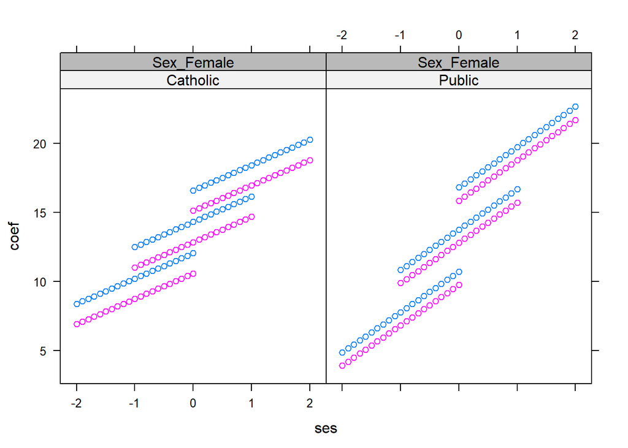

2. 1. Sex_Female = 0.5

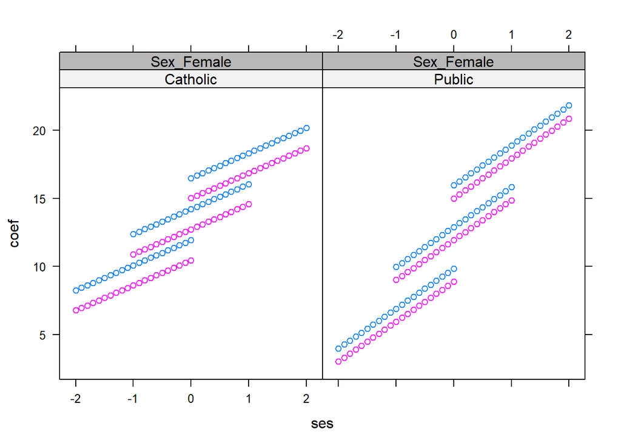

3. Sex_Female = 0.9

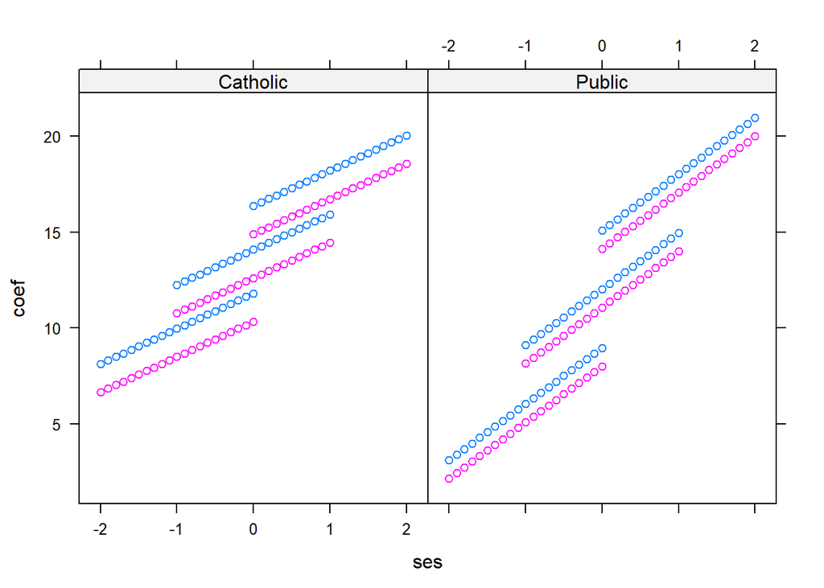

Conclusion: There seems to be only minor difference in the graph for the three propotions of female students (0.1, 0.5, 0.9), however the difference is more prominent in Public schools. Overall the gender gap is larger in Catholic schools.